# 项目：足球数据集调查

## 目录

- 简介
- 数据整理
- 探索性数据分析
- 结论

## 简介

哪支球队在2015/2016这段时间内的进球最多？  
哪位球员受罚最多？  
哪支球队赢得胜利的次数最多？什么样的球队特点更能帮助球队获胜？  
哪支球队胜率最高？

```python
# 导入包
import pandas as pd
import numpy as np
import matplotlib.pyplot as plt
% matplotlib inline
import seaborn as sn
import sqlite3
conn=sqlite3.connect('database.sqlite')
```

```python
# 每一个sqlite数据库都有一张叫做sqlite_master的系统表，以下语句“”获得数据库中所有表的列表
table_name=pd.read_sql("SELECT name FROM sqlite_master WHERE type='table'",conn)
table_name
```

|  | name |
| --- | --- |
| 0 | sqlite_sequence |
| 1 | Player_Attributes |
| 2 | Player |
| 3 | Match |
| 4 | League |
| 5 | Country |
| 6 | Team |
| 7 | Team_Attributes |

```python
# sqlite_sequence表也是SQLite的系统表。该表用来保存其他表的RowID的最大值。数据库被创建时，sqlite_sequence表会被自动创建。
table_name_use=pd.read_sql("SELECT * FROM sqlite_sequence",conn)
table_name_use
```

|  | name | seq |
| --- | --- | --- |
| 0 | Team | 103916 |
| 1 | Country | 51958 |
| 2 | League | 51958 |
| 3 | Match | 51958 |
| 4 | Player | 11075 |
| 5 | Player_Attributes | 183978 |
| 6 | Team_Attributes | 1458 |

```python
# 依照sqlite数据库中表，生成dataframe文件
table_Team=pd.read_sql('SELECT * FROM Team',conn)
table_Team.head(1)
```

|  | id | team_api_id | team_fifa_api_id | team_long_name | team_short_name |
| --- | --- | --- | --- | --- | --- |
| 0 | 1 | 9987 | 673.0 | KRC Genk | GEN |

```python
# 检查数据，返回随机的行
table_Team.sample(3)
```

|  | id | team_api_id | team_fifa_api_id | team_long_name | team_short_name |
| --- | --- | --- | --- | --- | --- |
| 26 | 3458 | 10261 | 13.0 | Newcastle United | NEW |
| 125 | 20514 | 8551 | 1838.0 | Siena | SIE |
| 4 | 5 | 9984 | 1750.0 | KSV Cercle Brugge | CEB |

```python
table_Country=pd.read_sql('SELECT * FROM Country',conn)
table_Country.head(1)
```

|  | id | name |
| --- | --- | --- |
| 0 | 1 | Belgium |

```python
table_League=pd.read_sql('SELECT * FROM League',conn)
table_League.sample(3)
```

|  | id | country_id | name |
| --- | --- | --- | --- |
| 8 | 19694 | 19694 | Scotland Premier League |
| 5 | 13274 | 13274 | Netherlands Eredivisie |
| 7 | 17642 | 17642 | Portugal Liga ZON Sagres |

```python
table_Match=pd.read_sql('SELECT * FROM Match',conn)
table_Match.sample(3)
```

|  | id | country_id | league_id | season | stage | date | match_api_id | home_team_api_id | away_team_api_id | home_team_goal | ... | SJA | VCH | VCD | VCA | GBH | GBD | GBA | BSH | BSD | BSA |
| --- | --- | --- | --- | --- | --- | --- | --- | --- | --- | --- | --- | --- | --- | --- | --- | --- | --- | --- | --- | --- | --- |
| 4303 | 4304 | 1729 | 1729 | 2014/2015 | 36 | 2015-05-09 00:00:00 | 1724337 | 8667 | 8191 | 0 | ... | NaN | 1.90 | 3.50 | 4.75 | NaN | NaN | NaN | NaN | NaN | NaN |
| 2899 | 2900 | 1729 | 1729 | 2011/2012 | 12 | 2011-11-19 00:00:00 | 1024792 | 8668 | 8602 | 2 | ... | 6.5 | 1.62 | 3.80 | 7.00 | 1.6 | 3.6 | 5.75 | 1.57 | 3.6 | 6.5 |
| 12779 | 12780 | 10257 | 10257 | 2014/2015 | 33 | 2015-04-28 00:00:00 | 1786336 | 8600 | 8636 | 1 | ... | NaN | 3.50 | 3.25 | 2.30 | NaN | NaN | NaN | NaN | NaN | NaN |

3 rows × 115 columns

```python
table_Player=pd.read_sql('SELECT * FROM Player',conn)
table_Player.sample(3)
```

|  | id | player_api_id | player_name | player_fifa_api_id | birthday | height | weight |
| --- | --- | --- | --- | --- | --- | --- | --- |
| 8185 | 8197 | 33892 | Oscar Serrano | 145651 | 1981-09-30 00:00:00 | 172.72 | 161 |
| 5841 | 5848 | 429265 | Kingsley Coman | 213345 | 1996-06-13 00:00:00 | 177.80 | 157 |
| 6890 | 6900 | 358759 | Marko Bakic | 211574 | 1993-11-01 00:00:00 | 185.42 | 161 |

```python
table_Player_Attributes=pd.read_sql('SELECT * FROM Player_Attributes',conn)
table_Player_Attributes.head(1)
```

|  | id | player_fifa_api_id | player_api_id | date | overall_rating | potential | preferred_foot | attacking_work_rate | defensive_work_rate | crossing | ... | vision | penalties | marking | standing_tackle | sliding_tackle | gk_diving | gk_handling | gk_kicking | gk_positioning | gk_reflexes |
| --- | --- | --- | --- | --- | --- | --- | --- | --- | --- | --- | --- | --- | --- | --- | --- | --- | --- | --- | --- | --- | --- |
| 0 | 1 | 218353 | 505942 | 2016-02-18 00:00:00 | 67.0 | 71.0 | right | medium | medium | 49.0 | ... | 54.0 | 48.0 | 65.0 | 69.0 | 69.0 | 6.0 | 11.0 | 10.0 | 8.0 | 8.0 |

1 rows × 42 columns

```python
table_Team_Attributes=pd.read_sql('SELECT * FROM Team_Attributes',conn)
table_Team_Attributes.head(1)
```

|  | id | team_fifa_api_id | team_api_id | date | buildUpPlaySpeed | buildUpPlaySpeedClass | buildUpPlayDribbling | buildUpPlayDribblingClass | buildUpPlayPassing | buildUpPlayPassingClass | ... | chanceCreationShooting | chanceCreationShootingClass | chanceCreationPositioningClass | defencePressure | defencePressureClass | defenceAggression | defenceAggressionClass | defenceTeamWidth | defenceTeamWidthClass | defenceDefenderLineClass |
| --- | --- | --- | --- | --- | --- | --- | --- | --- | --- | --- | --- | --- | --- | --- | --- | --- | --- | --- | --- | --- | --- |
| 0 | 1 | 434 | 9930 | 2010-02-22 00:00:00 | 60 | Balanced | NaN | Little | 50 | Mixed | ... | 55 | Normal | Organised | 50 | Medium | 55 | Press | 45 | Normal | Cover |

1 rows × 25 columns

```python
# 选择所需要的列，生成dataframe文件
df_tta=pd.read_sql("""
                          SELECT t.team_api_id,t.team_short_name,t.team_long_name
                                 ,ta.date,ta.buildUpPlaySpeed,ta.chanceCreationPassing,ta.chanceCreationShooting,defencePressure
                          FROM Team t
                          JOIN Team_Attributes ta
                          ON t.team_api_id=ta.team_api_id;
                          """,conn)
```

```python
df_ppa=pd.read_sql("""
                          SELECT p.player_api_id,p.player_name,p.birthday,p.height,p.weight
                                 ,pa.date,pa.overall_rating,pa.potential,pa.aggression,pa.interceptions,pa.vision,pa.penalties
                          FROM Player p
                          JOIN Player_Attributes pa
                          ON p.player_api_id=pa.player_api_id;
                          """,conn)
```

```python
df_mclt=pd.read_sql("""
                          SELECT m.country_id,c.name AS country_name,m.league_id,l.name AS league_name,m.season,m.stage,m.date
                                ,m.home_team_api_id,m.away_team_api_id,m.home_team_goal,m.away_team_goal,t.team_short_name AS home_team_name
                          FROM Match m
                          JOIN Country c
                          ON m.country_id=c.id
                          JOIN League l
                          ON m.league_id=l.id
                          JOIN Team t
                          ON t.team_api_id=m.home_team_api_id;
                          """,conn)
```

```python
conn.close()
```

## 数据整理

### 常规属性

```python
# 加载数据并打印几行。进行几项操作，检查数据
#   类型，以及是否有缺失数据或错误数据。
df_mclt.head()
```

|  | country_id | country_name | league_id | league_name | season | stage | date | home_team_api_id | away_team_api_id | home_team_goal | away_team_goal | home_team_name |
| --- | --- | --- | --- | --- | --- | --- | --- | --- | --- | --- | --- | --- |
| 0 | 1 | Belgium | 1 | Belgium Jupiler League | 2008/2009 | 1 | 2008-08-17 00:00:00 | 9987 | 9993 | 1 | 1 | GEN |
| 1 | 1 | Belgium | 1 | Belgium Jupiler League | 2008/2009 | 1 | 2008-08-16 00:00:00 | 10000 | 9994 | 0 | 0 | ZUL |
| 2 | 1 | Belgium | 1 | Belgium Jupiler League | 2008/2009 | 1 | 2008-08-16 00:00:00 | 9984 | 8635 | 0 | 3 | CEB |
| 3 | 1 | Belgium | 1 | Belgium Jupiler League | 2008/2009 | 1 | 2008-08-17 00:00:00 | 9991 | 9998 | 5 | 0 | GEN |
| 4 | 1 | Belgium | 1 | Belgium Jupiler League | 2008/2009 | 1 | 2008-08-16 00:00:00 | 7947 | 9985 | 1 | 3 | DEN |

```python
df_tta.head()
```

|  | team_api_id | team_short_name | team_long_name | date | buildUpPlaySpeed | chanceCreationPassing | chanceCreationShooting | defencePressure |
| --- | --- | --- | --- | --- | --- | --- | --- | --- |
| 0 | 9930 | AAR | FC Aarau | 2010-02-22 00:00:00 | 60 | 60 | 55 | 50 |
| 1 | 9930 | AAR | FC Aarau | 2014-09-19 00:00:00 | 52 | 54 | 64 | 47 |
| 2 | 9930 | AAR | FC Aarau | 2015-09-10 00:00:00 | 47 | 54 | 64 | 47 |
| 3 | 8485 | ABE | Aberdeen | 2010-02-22 00:00:00 | 70 | 70 | 70 | 60 |
| 4 | 8485 | ABE | Aberdeen | 2011-02-22 00:00:00 | 47 | 53 | 52 | 47 |

```python
df_ppa.head()
```

|  | player_api_id | player_name | birthday | height | weight | date | overall_rating | potential | aggression | interceptions | vision | penalties |
| --- | --- | --- | --- | --- | --- | --- | --- | --- | --- | --- | --- | --- |
| 0 | 505942 | Aaron Appindangoye | 1992-02-29 00:00:00 | 182.88 | 187 | 2016-02-18 00:00:00 | 67.0 | 71.0 | 71.0 | 70.0 | 54.0 | 48.0 |
| 1 | 505942 | Aaron Appindangoye | 1992-02-29 00:00:00 | 182.88 | 187 | 2015-11-19 00:00:00 | 67.0 | 71.0 | 71.0 | 70.0 | 54.0 | 48.0 |
| 2 | 505942 | Aaron Appindangoye | 1992-02-29 00:00:00 | 182.88 | 187 | 2015-09-21 00:00:00 | 62.0 | 66.0 | 63.0 | 41.0 | 54.0 | 48.0 |
| 3 | 505942 | Aaron Appindangoye | 1992-02-29 00:00:00 | 182.88 | 187 | 2015-03-20 00:00:00 | 61.0 | 65.0 | 62.0 | 40.0 | 53.0 | 47.0 |
| 4 | 505942 | Aaron Appindangoye | 1992-02-29 00:00:00 | 182.88 | 187 | 2007-02-22 00:00:00 | 61.0 | 65.0 | 62.0 | 40.0 | 53.0 | 47.0 |

```python
df_mclt.info()
```

```
<class 'pandas.core.frame.DataFrame'>
RangeIndex: 25979 entries, 0 to 25978
Data columns (total 12 columns):
country_id          25979 non-null int64
country_name        25979 non-null object
league_id           25979 non-null int64
league_name         25979 non-null object
season              25979 non-null object
stage               25979 non-null int64
date                25979 non-null object
home_team_api_id    25979 non-null int64
away_team_api_id    25979 non-null int64
home_team_goal      25979 non-null int64
away_team_goal      25979 non-null int64
home_team_name      25979 non-null object
dtypes: int64(7), object(5)
memory usage: 1.9+ MB
```

```python
df_tta.info()
```

```
<class 'pandas.core.frame.DataFrame'>
RangeIndex: 1458 entries, 0 to 1457
Data columns (total 8 columns):
team_api_id               1458 non-null int64
team_short_name           1458 non-null object
team_long_name            1458 non-null object
date                      1458 non-null object
buildUpPlaySpeed          1458 non-null int64
chanceCreationPassing     1458 non-null int64
chanceCreationShooting    1458 non-null int64
defencePressure           1458 non-null int64
dtypes: int64(5), object(3)
memory usage: 74.1+ KB
```

```python
df_ppa.info()
```

```
<class 'pandas.core.frame.DataFrame'>
RangeIndex: 183978 entries, 0 to 183977
Data columns (total 12 columns):
player_api_id     183978 non-null int64
player_name       183978 non-null object
birthday          183978 non-null object
height            183978 non-null float64
weight            183978 non-null int64
date              183978 non-null object
overall_rating    183142 non-null float64
potential         183142 non-null float64
aggression        183142 non-null float64
interceptions     183142 non-null float64
vision            181265 non-null float64
penalties         183142 non-null float64
dtypes: float64(7), int64(2), object(3)
memory usage: 14.7+ MB
```

```python
df_mclt.shape
```

```
(25979, 12)
```

```python
df_tta.shape
```

```
(1458, 8)
```

```python
df_ppa.shape
```

```
(183978, 12)
```

```python
df_mclt.isnull().sum().any()
```

```
False
```

```python
df_tta.isnull().sum().any()
```

```
False
```

```python
df_ppa.isnull().sum()
```

```
player_api_id        0
player_name          0
birthday             0
height               0
weight               0
date                 0
overall_rating     836
potential          836
aggression         836
interceptions      836
vision            2713
penalties          836
dtype: int64
```

```python
df_mclt.describe()
```

|  | country_id | league_id | stage | home_team_api_id | away_team_api_id | home_team_goal | away_team_goal |
| --- | --- | --- | --- | --- | --- | --- | --- |
| count | 25979.000000 | 25979.000000 | 25979.000000 | 25979.000000 | 25979.000000 | 25979.000000 | 25979.000000 |
| mean | 11738.630317 | 11738.630317 | 18.242773 | 9984.371993 | 9984.475115 | 1.544594 | 1.160938 |
| std | 7553.936759 | 7553.936759 | 10.407354 | 14087.453758 | 14087.445135 | 1.297158 | 1.142110 |
| min | 1.000000 | 1.000000 | 1.000000 | 1601.000000 | 1601.000000 | 0.000000 | 0.000000 |
| 25% | 4769.000000 | 4769.000000 | 9.000000 | 8475.000000 | 8475.000000 | 1.000000 | 0.000000 |
| 50% | 10257.000000 | 10257.000000 | 18.000000 | 8697.000000 | 8697.000000 | 1.000000 | 1.000000 |
| 75% | 17642.000000 | 17642.000000 | 27.000000 | 9925.000000 | 9925.000000 | 2.000000 | 2.000000 |
| max | 24558.000000 | 24558.000000 | 38.000000 | 274581.000000 | 274581.000000 | 10.000000 | 9.000000 |

```python
df_tta.describe()
```

|  | team_api_id | buildUpPlaySpeed | chanceCreationPassing | chanceCreationShooting | defencePressure |
| --- | --- | --- | --- | --- | --- |
| count | 1458.000000 | 1458.000000 | 1458.000000 | 1458.000000 | 1458.000000 |
| mean | 9995.727023 | 52.462277 | 52.165295 | 53.969136 | 46.017147 |
| std | 13264.869900 | 11.545869 | 10.360793 | 10.327566 | 10.227225 |
| min | 1601.000000 | 20.000000 | 21.000000 | 22.000000 | 23.000000 |
| 25% | 8457.750000 | 45.000000 | 46.000000 | 48.000000 | 39.000000 |
| 50% | 8674.000000 | 52.000000 | 52.000000 | 53.000000 | 45.000000 |
| 75% | 9904.000000 | 62.000000 | 59.000000 | 61.000000 | 51.000000 |
| max | 274581.000000 | 80.000000 | 80.000000 | 80.000000 | 72.000000 |

```python
df_ppa.describe()
```

|  | player_api_id | height | weight | overall_rating | potential | aggression | interceptions | vision | penalties |
| --- | --- | --- | --- | --- | --- | --- | --- | --- | --- |
| count | 183978.000000 | 183978.000000 | 183978.000000 | 183142.000000 | 183142.000000 | 183142.000000 | 183142.000000 | 181265.000000 | 183142.000000 |
| mean | 135900.617324 | 181.878872 | 168.776245 | 68.600015 | 73.460353 | 60.948046 | 52.009271 | 57.873550 | 55.003986 |
| std | 136927.840510 | 6.394818 | 15.088920 | 7.041139 | 6.592271 | 16.089521 | 19.450133 | 15.144086 | 15.546519 |
| min | 2625.000000 | 157.480000 | 117.000000 | 33.000000 | 39.000000 | 6.000000 | 1.000000 | 1.000000 | 2.000000 |
| 25% | 34763.000000 | 177.800000 | 159.000000 | 64.000000 | 69.000000 | 51.000000 | 34.000000 | 49.000000 | 45.000000 |
| 50% | 77741.000000 | 182.880000 | 168.000000 | 69.000000 | 74.000000 | 64.000000 | 57.000000 | 60.000000 | 57.000000 |
| 75% | 191080.000000 | 185.420000 | 179.000000 | 73.000000 | 78.000000 | 73.000000 | 68.000000 | 69.000000 | 67.000000 |
| max | 750584.000000 | 208.280000 | 243.000000 | 94.000000 | 97.000000 | 97.000000 | 96.000000 | 97.000000 | 96.000000 |

```python
df_mclt.duplicated().sum()
```

```
0
```

```python
df_tta.duplicated().sum()
```

```
1
```

```python
df_ppa.duplicated().sum()
```

```
1
```

### 数据清理

```python
# 用均值填充缺失值
for col in list(df_ppa.columns[df_ppa.isnull().sum()>0]):
    mean_value=df_ppa[col].mean()
    df_ppa[col].fillna(mean_value,inplace=True)
```

```python
# 删除冗余行并更新数据框
df_tta.drop_duplicates(inplace=True)
df_ppa.drop_duplicates(inplace=True)
```

## 探索性数据分析

### 研究问题 1

**哪支球队在2015/2016这段时间内的进球最多？**

REA在2015/2016这段时间内的进球最多,主场和客场的平均单场进球数最高,单场进球数达2.26个。

```python
df_mclt.head()
```

|  | country_id | country_name | league_id | league_name | season | stage | date | home_team_api_id | away_team_api_id | home_team_goal | away_team_goal | home_team_name |
| --- | --- | --- | --- | --- | --- | --- | --- | --- | --- | --- | --- | --- |
| 0 | 1 | Belgium | 1 | Belgium Jupiler League | 2008/2009 | 1 | 2008-08-17 00:00:00 | 9987 | 9993 | 1 | 1 | GEN |
| 1 | 1 | Belgium | 1 | Belgium Jupiler League | 2008/2009 | 1 | 2008-08-16 00:00:00 | 10000 | 9994 | 0 | 0 | ZUL |
| 2 | 1 | Belgium | 1 | Belgium Jupiler League | 2008/2009 | 1 | 2008-08-16 00:00:00 | 9984 | 8635 | 0 | 3 | CEB |
| 3 | 1 | Belgium | 1 | Belgium Jupiler League | 2008/2009 | 1 | 2008-08-17 00:00:00 | 9991 | 9998 | 5 | 0 | GEN |
| 4 | 1 | Belgium | 1 | Belgium Jupiler League | 2008/2009 | 1 | 2008-08-16 00:00:00 | 7947 | 9985 | 1 | 3 | DEN |

```python
# 哪支球队在2015/2016这段时间内 home_team_api_id和away_team_goal的单场平均进球数和最高
s_goal=(df_mclt[df_mclt['season']=='2015/2016'].groupby(['home_team_api_id'])['home_team_goal'].mean()+df_mclt[df_mclt['season']=='2015/2016'].groupby(['home_team_api_id'])['away_team_goal'].mean())/2
id_most_1516=s_goal.argmax()
```

```python
s_goal.max()
```

```
2.263157894736842
```

```python
# 球队名是什么
df_mclt[df_mclt['home_team_api_id']==id_most_1516]['home_team_name'].unique()
```

```
array(['REA'], dtype=object)
```

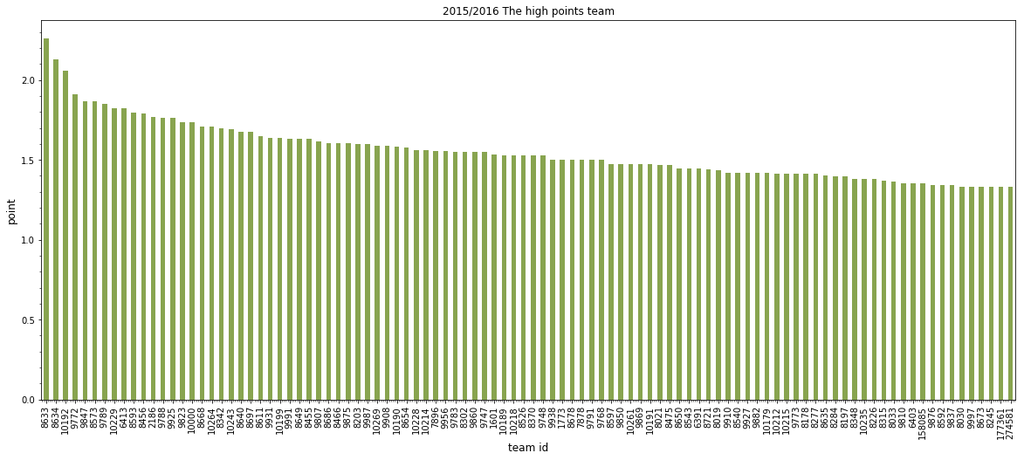

```python
# 2015/2016每个球队主场和客场的平均单场进球数和前100名
s_goal.sort_values(ascending=False)[:100].plot(kind='bar',color = '#6B8E23',alpha=0.8,figsize=(20,8));

plt.title('2015/2016 The high points team',fontsize=12);
plt.xlabel('team id',fontsize=12);
plt.ylabel('point',fontsize=12);
plt.minorticks_on()
```

### 研究问题 2

**哪位球员受罚最多？**

Rickie Lambert受罚最多,多达96次

```python
df_ppa.head()
```

|  | player_api_id | player_name | birthday | height | weight | date | overall_rating | potential | aggression | interceptions | vision | penalties |
| --- | --- | --- | --- | --- | --- | --- | --- | --- | --- | --- | --- | --- |
| 0 | 505942 | Aaron Appindangoye | 1992-02-29 00:00:00 | 182.88 | 187 | 2016-02-18 00:00:00 | 67.0 | 71.0 | 71.0 | 70.0 | 54.0 | 48.0 |
| 1 | 505942 | Aaron Appindangoye | 1992-02-29 00:00:00 | 182.88 | 187 | 2015-11-19 00:00:00 | 67.0 | 71.0 | 71.0 | 70.0 | 54.0 | 48.0 |
| 2 | 505942 | Aaron Appindangoye | 1992-02-29 00:00:00 | 182.88 | 187 | 2015-09-21 00:00:00 | 62.0 | 66.0 | 63.0 | 41.0 | 54.0 | 48.0 |
| 3 | 505942 | Aaron Appindangoye | 1992-02-29 00:00:00 | 182.88 | 187 | 2015-03-20 00:00:00 | 61.0 | 65.0 | 62.0 | 40.0 | 53.0 | 47.0 |
| 4 | 505942 | Aaron Appindangoye | 1992-02-29 00:00:00 | 182.88 | 187 | 2007-02-22 00:00:00 | 61.0 | 65.0 | 62.0 | 40.0 | 53.0 | 47.0 |

```python
# 受罚最多球员id
id_most_pen=df_ppa['penalties'].argmax()
id_most_pen
```

```
149591
```

```python
df_ppa.iloc[id_most_pen]
```

```
player_api_id                   39225
player_name            Rickie Lambert
birthday          1982-02-16 00:00:00
height                         187.96
weight                            170
date              2015-12-24 00:00:00
overall_rating                     75
potential                          75
aggression                         76
interceptions                      32
vision                             77
penalties                          96
Name: 149592, dtype: object
```

```python
# 哪位球员受罚最多
df_ppa.iloc[id_most_pen].player_name
```

```
'Rickie Lambert'
```

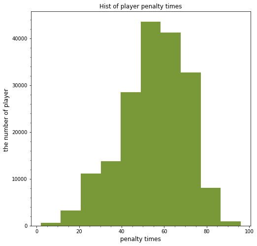

```python
# 受罚次数直方图
df_ppa['penalties'].plot(kind='hist',color = '#6B8E23',alpha=0.9,figsize=(8,8));

plt.title('Hist of player penalty times',fontsize=12);
plt.xlabel('penalty times',fontsize=12);
plt.ylabel('the number of player ',fontsize=12);
plt.minorticks_on()
```

### 研究问题 3

**哪支球队赢得胜利的次数最多？**

西班牙的皇家马德里Real Madrid CF胜利次数最多，获胜次数达141次。

FIFA国际足联战术设计的三个基本部分buildUpPlay、chanceCreation、defence，决定了一支球队的进攻和防守方式。

BuildUpPlaySpeed抢下球反击的推进速度，Real Madrid CF平均50.666667。所有队平均52.463967  
ChanceCreationPassing传球，Real Madrid CF平均67.5。所有队平均52.166781  
ChanceCreationShooting射门，Real Madrid CF平均69。所有队平均53.971860  
DefencePressure防守紧逼，Real Madrid CF平均52。所有队平均46.017845

反击稳，射门准，防守狠

```python
df_mclt.sample(2)
```

|  | country_id | country_name | league_id | league_name | season | stage | date | home_team_api_id | away_team_api_id | home_team_goal | away_team_goal | home_team_name |
| --- | --- | --- | --- | --- | --- | --- | --- | --- | --- | --- | --- | --- |
| 8677 | 7809 | Germany | 7809 | Germany 1. Bundesliga | 2010/2011 | 4 | 2010-09-18 00:00:00 | 8721 | 9904 | 2 | 0 | WOL |
| 7133 | 4769 | France | 4769 | France Ligue 1 | 2014/2015 | 17 | 2014-12-06 00:00:00 | 9847 | 9830 | 2 | 1 | PSG |

```python
df_tta.sample(2)
```

|  | team_api_id | team_short_name | team_long_name | date | buildUpPlaySpeed | chanceCreationPassing | chanceCreationShooting | defencePressure |
| --- | --- | --- | --- | --- | --- | --- | --- | --- |
| 1308 | 10267 | VAL | Valencia CF | 2011-02-22 00:00:00 | 41 | 56 | 64 | 40 |
| 773 | 10199 | LUZ | FC Luzern | 2013-09-20 00:00:00 | 46 | 51 | 55 | 48 |

```python
# 按win是true还是false新增列
df_mclt['home_win']=df_mclt['home_team_goal']>df_mclt['away_team_goal']
df_mclt['away_win']=df_mclt['home_team_goal']<df_mclt['away_team_goal']
df_mclt['draw']=df_mclt['home_team_goal']==df_mclt['away_team_goal']
```

```python
# 每个球队赢球的次数
s_win=df_mclt.groupby(['home_team_api_id'])['home_win'].sum()+df_mclt.groupby(['home_team_api_id'])['away_win'].sum()
id_most_w=s_win.argmax()
id_most_w
```

```
8633
```

```python
s_win_name=df_mclt.groupby(['home_team_name'])['home_win'].sum()+df_mclt.groupby(['home_team_name'])['away_win'].sum()
```

```python
s_win.max()
```

```
141.0
```

```python
# 什么样的球队特点赢得的胜利次数最多?查看id=8633的球队特点
df_tta[df_tta.team_api_id==id_most_w]
```

|  | team_api_id | team_short_name | team_long_name | date | buildUpPlaySpeed | chanceCreationPassing | chanceCreationShooting | defencePressure |
| --- | --- | --- | --- | --- | --- | --- | --- | --- |
| 1048 | 8633 | REA | Real Madrid CF | 2010-02-22 00:00:00 | 55 | 70 | 70 | 65 |
| 1049 | 8633 | REA | Real Madrid CF | 2011-02-22 00:00:00 | 54 | 67 | 67 | 68 |
| 1050 | 8633 | REA | Real Madrid CF | 2012-02-22 00:00:00 | 45 | 71 | 73 | 49 |
| 1051 | 8633 | REA | Real Madrid CF | 2013-09-20 00:00:00 | 50 | 68 | 72 | 39 |
| 1052 | 8633 | REA | Real Madrid CF | 2014-09-19 00:00:00 | 50 | 68 | 69 | 39 |
| 1053 | 8633 | REA | Real Madrid CF | 2015-09-10 00:00:00 | 50 | 61 | 63 | 52 |

```python
df_tta[df_tta.team_api_id==id_most_w].describe()
```

|  | team_api_id | buildUpPlaySpeed | chanceCreationPassing | chanceCreationShooting | defencePressure |
| --- | --- | --- | --- | --- | --- |
| count | 6.0 | 6.000000 | 6.000000 | 6.00000 | 6.00000 |
| mean | 8633.0 | 50.666667 | 67.500000 | 69.00000 | 52.00000 |
| std | 0.0 | 3.559026 | 3.507136 | 3.63318 | 12.42578 |
| min | 8633.0 | 45.000000 | 61.000000 | 63.00000 | 39.00000 |
| 25% | 8633.0 | 50.000000 | 67.250000 | 67.50000 | 41.50000 |
| 50% | 8633.0 | 50.000000 | 68.000000 | 69.50000 | 50.50000 |
| 75% | 8633.0 | 53.000000 | 69.500000 | 71.50000 | 61.75000 |
| max | 8633.0 | 55.000000 | 71.000000 | 73.00000 | 68.00000 |

```python
df_tta.describe()
```

|  | team_api_id | buildUpPlaySpeed | chanceCreationPassing | chanceCreationShooting | defencePressure |
| --- | --- | --- | --- | --- | --- |
| count | 1457.000000 | 1457.000000 | 1457.000000 | 1457.000000 | 1457.000000 |
| mean | 9995.726836 | 52.463967 | 52.166781 | 53.971860 | 46.017845 |
| std | 13269.424362 | 11.549653 | 10.364195 | 10.330588 | 10.230702 |
| min | 1601.000000 | 20.000000 | 21.000000 | 22.000000 | 23.000000 |
| 25% | 8457.000000 | 45.000000 | 46.000000 | 48.000000 | 39.000000 |
| 50% | 8674.000000 | 52.000000 | 52.000000 | 53.000000 | 45.000000 |
| 75% | 9904.000000 | 62.000000 | 59.000000 | 61.000000 | 51.000000 |
| max | 274581.000000 | 80.000000 | 80.000000 | 80.000000 | 72.000000 |

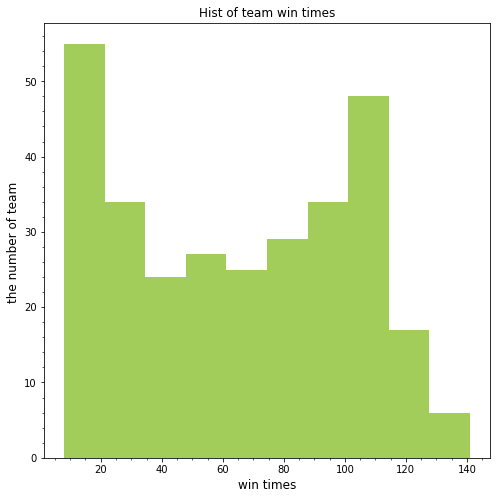

```python
# 球队赢球次数直方图
s_win.plot(kind='hist',color = '#A2CD5A',figsize=(8,8));

plt.title('Hist of team win times',fontsize=12);
plt.xlabel('win times',fontsize=12);
plt.ylabel('the number of team ',fontsize=12);
plt.minorticks_on()
```

**什么样的球队特点更能帮助球队获胜？**

FIFA国际足联战术设计的三个基本部分buildUpPlay、chanceCreation、defence，决定了一支球队的进攻和防守方式。

所有球队的赢球次数win_times ，和 BuildUpPlaySpeed抢下球反击的推进速度，的相关系数0.015210 所有球队的赢球次数win_times，和ChanceCreationPassing传球，的相关系数0.158445 所有球队的赢球次数win_times，和ChanceCreationShooting射门，的相关系数0.076760 所有球队的赢球次数win_times，和DefencePressure防守紧逼，的相关系数0.174965

多传球、重防守的特点更能帮助球队获胜。

```python
# 赢球次数最多的10个球队，赢球次数和id
s_win.sort_values(ascending=False).head(10)
```

```
home_team_api_id
8633     141.0
8634     140.0
10260    136.0
8456     134.0
9925     129.0
9906     128.0
8302     125.0
9823     122.0
9885     121.0
8315     121.0
dtype: float64
```

```python
# 赢球次数最多的10个球队名字
b=s_win_name.nlargest(10).index.values
b
```

```
array(['GEN', 'VAL', 'GRA', 'MON', 'MAR', 'LEV', 'MAL', 'CEL', 'NAC', 'BAS'], dtype=object)
```

```python
# 数组b转换为列表b
b=b.tolist()
```

```python
# 合并各队历次参加比赛特点参数的平均值，作为此队此特点参数
df_tta_con_name=df_tta.groupby('team_short_name')['buildUpPlaySpeed','chanceCreationPassing','chanceCreationShooting','defencePressure'].mean()
```

```python
# 赢球次数最多的10个球队特点参数
df_top10_name=df_tta_con_name.query('team_short_name==@b')
df_top10_name
```

| team_short_name | buildUpPlaySpeed | chanceCreationPassing | chanceCreationShooting | defencePressure |
| --- | --- | --- | --- | --- |
| BAS | 54.363636 | 57.000000 | 51.454545 | 47.909091 |
| CEL | 55.000000 | 54.166667 | 58.416667 | 48.000000 |
| GEN | 57.777778 | 53.833333 | 49.222222 | 46.555556 |
| GRA | 48.153846 | 56.461538 | 53.230769 | 43.846154 |
| LEV | 60.666667 | 58.666667 | 55.583333 | 49.166667 |
| MAL | 52.333333 | 55.416667 | 53.833333 | 54.750000 |
| MAR | 48.500000 | 56.916667 | 58.000000 | 44.500000 |
| MON | 50.533333 | 49.466667 | 45.866667 | 45.533333 |
| NAC | 44.333333 | 46.833333 | 51.333333 | 40.333333 |
| VAL | 45.222222 | 48.222222 | 55.722222 | 45.833333 |

```python
# 赢球次数最多的10个球队，特点参数的平均值
df_top10_name.mean()
```

```
buildUpPlaySpeed          51.688415
chanceCreationPassing     53.698376
chanceCreationShooting    53.266309
defencePressure           46.642747
dtype: float64
```

```python
# 所有球队，特点参数的平均值（此数值为先按球队分组，再计算每个球队特点平均值，再按球队个数求平均值。与特点参数直接按数据条数求平均值的数值不同）
df_tta_con_name.mean()
```

```
buildUpPlaySpeed          52.326504
chanceCreationPassing     51.722985
chanceCreationShooting    53.792912
defencePressure           45.716482
dtype: float64
```

```python
s_distance=df_top10_name.mean()-df_tta_con_name.mean()
```

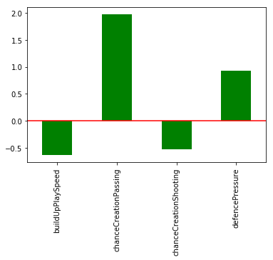

```python
# # 赢球次数最多的10个球队参数特点平均值，与所有球队参数特点平均值 比较
s_distance.plot(kind='bar',color = 'g');
plt.axhline(0, color='r');
```

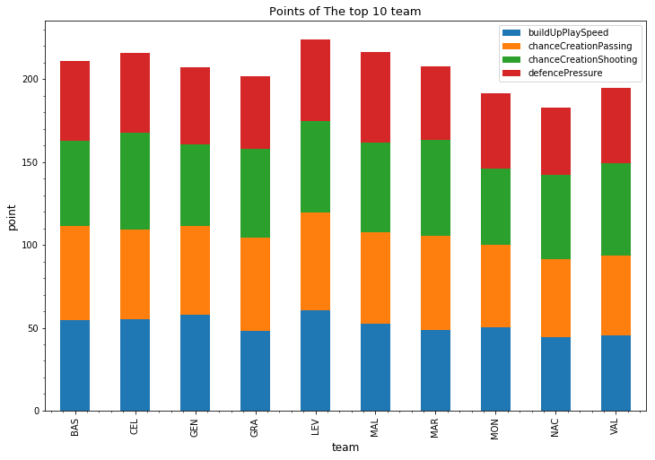

```python
# 赢球次数最多的10个球队,参数特点堆叠比较
df_top10_name.plot.bar(stacked=True,figsize=(12,8));
plt.title('Points of The top 10 team',fontsize=13);
plt.xlabel('team',fontsize=12);
plt.ylabel('point',fontsize=12);
plt.minorticks_on();
```

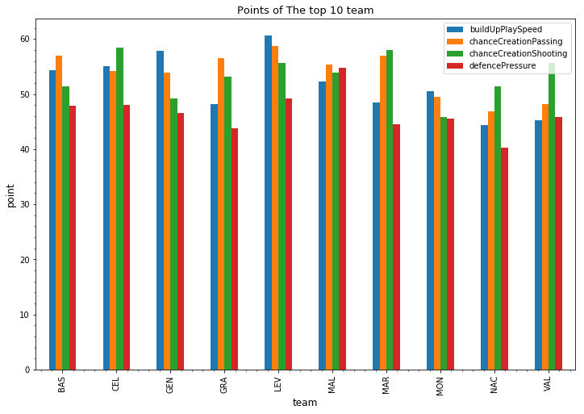

```python
# 赢球次数最多的10个球队,参数特点横向比较
df_top10_name.plot.bar(figsize=(12,8));
plt.title('Points of The top 10 team',fontsize=13);
plt.xlabel('team',fontsize=12);
plt.ylabel('point',fontsize=12);
plt.minorticks_on();
```

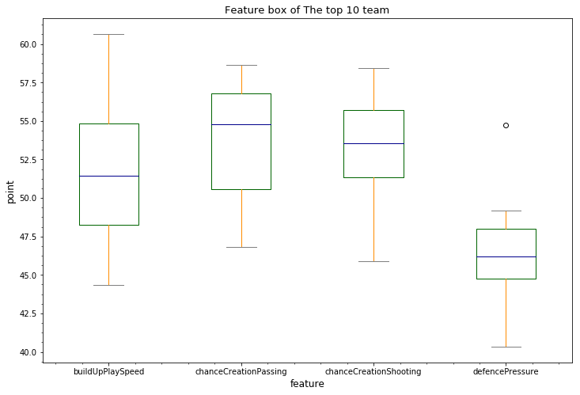

```python
# 赢球次数最多的10个球队,参数特点范围、最大值、最小值、中位数比较
color = dict(boxes='DarkGreen', whiskers='DarkOrange',medians='DarkBlue', caps='Gray')
df_top10_name.plot.box(figsize=(12,8),color=color);
plt.title('Feature box of The top 10 team',fontsize=13);
plt.xlabel('feature',fontsize=12);
plt.ylabel('point',fontsize=12);
plt.minorticks_on();
```

**赢球次数和球队特点各参数之间的相关系数**

```python
df_win_name=s_win_name.reset_index()
```

```python
df_win_name=df_win_name.rename(columns={0:'win_times','home_team_name':'team_short_name'})
```

```python
df_tta_con_name=df_tta_con_name.reset_index()
```

```python
df_cor=pd.merge(df_win_name,df_tta_con_name,left_on='team_short_name',right_on='team_short_name',how='left')
df_cor.sample(2)
```

|  | team_short_name | win_times | buildUpPlaySpeed | chanceCreationPassing | chanceCreationShooting | defencePressure |
| --- | --- | --- | --- | --- | --- | --- |
| 221 | THU | 70.0 | 56.6 | 63.200000 | 59.0 | 45.0 |
| 16 | AUX | 49.0 | 53.5 | 45.666667 | 47.5 | 33.5 |

```python
# 赢球次数和球队特点各参数之间的相关系数
df_cor.corr()
```

|  | win_times | buildUpPlaySpeed | chanceCreationPassing | chanceCreationShooting | defencePressure |
| --- | --- | --- | --- | --- | --- |
| win_times | 1.000000 | 0.015210 | 0.158445 | 0.076760 | 0.174965 |
| buildUpPlaySpeed | 0.015210 | 1.000000 | 0.404021 | 0.051592 | -0.136215 |
| chanceCreationPassing | 0.158445 | 0.404021 | 1.000000 | 0.135995 | 0.173359 |
| chanceCreationShooting | 0.076760 | 0.051592 | 0.135995 | 1.000000 | 0.303604 |
| defencePressure | 0.174965 | -0.136215 | 0.173359 | 0.303604 | 1.000000 |

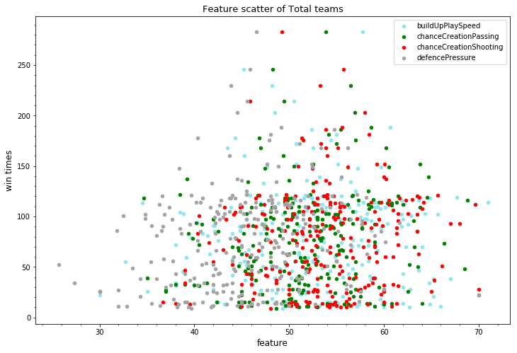

```python
# 所有球队赢球次数和球队特点各参数散点图
ax = df_cor.plot.scatter(x='buildUpPlaySpeed', y='win_times',color='#8EE5EE', label='buildUpPlaySpeed',figsize=(12,8));
df_cor.plot.scatter(x='chanceCreationPassing', y='win_times',color='g', label='chanceCreationPassing',ax=ax);
df_cor.plot.scatter(x='chanceCreationShooting', y='win_times',color='r', label='chanceCreationShooting',ax=ax);
df_cor.plot.scatter(x='defencePressure', y='win_times',color='#A3A3A3', label='defencePressure',ax=ax);

plt.title('Feature scatter of Total teams',fontsize=13);
plt.xlabel('feature',fontsize=12);
plt.ylabel('win times',fontsize=12);
plt.minorticks_on();
```

### 研究问题 4

**哪支球队胜率最高？**

法国的勒阿弗尔Le Havre AC的胜率最高，胜率高达50%

```python
# 每个球队的参数次数
s_in=df_mclt.groupby(['home_team_api_id']).date.count()+df_mclt.groupby(['away_team_api_id']).date.count()
```

```python
# 每个球队的胜率
s_rate=s_win/s_in
```

```python
id_most_wp=s_rate.argmax()
id_most_wp
```

```
9746
```

```python
s_rate.max()
```

```
0.5
```

```python
df_tta[df_tta.team_api_id==id_most_wp].team_long_name.unique()
```

```
array(['Le Havre AC'], dtype=object)
```

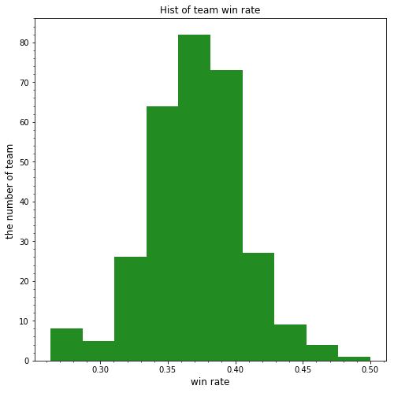

```python
# 球队胜率直方图
s_rate.plot(kind='hist',color = '#228B22',figsize=(8,8));

plt.title('Hist of team win rate',fontsize=12);
plt.xlabel('win rate',fontsize=12);
plt.ylabel('the number of team ',fontsize=12);
plt.minorticks_on()
```

## 结论

Rickie Lambert是2008-2016赛事中,受罚最多的球员,受罚多达96次

法国的勒阿弗尔队Le Havre AC，在2008-2016赛事中的胜率最高，胜率高达50%

西班牙的皇家马德里Real Madrid CF，在2015/2016赛事中表现最好,主场和客场的平均单场进球数最高,单场进球数达2.26个。  
同时，西班牙的皇家马德里Real Madrid CF也是2008-2016赛事中，胜利次数最多的球队，获胜次数达141次。  
皇家马德里的球队特点：反击稳，射门准，防守狠

FIFA国际足联战术设计的三个基本部分buildUpPlay、chanceCreation、defence，决定了一支球队的进攻和防守方式。

所有球队的赢球次数win_times ，和 BuildUpPlaySpeed抢下球反击的推进速度，的相关系数0.015210  
所有球队的赢球次数win_times，和ChanceCreationPassing传球，的相关系数0.158445  
所有球队的赢球次数win_times，和ChanceCreationShooting射门，的相关系数0.076760  
所有球队的赢球次数win_times，和DefencePressure防守紧逼，的相关系数0.174965

多传球、重防守的特点更能帮助球队获胜。

此次项目分析使用的数据，对于探索分析目标足够全面完善。  
数据量足够大。  
已有特征足够探索分析目标。  
探索过程中对数据的处理：“用均值填充缺失值”不会给数据分析的结论带来影响，不会对结论带来偏差和不确定性。此次探索分析的问题与用均值的数据几乎不相关。

```python
from subprocess import call
call(['python', '-m', 'nbconvert', 'Investigate_a_Dataset.ipynb'])
```

```
4294967295
```